# DCPP Group Project - World Crop Database - EDA report

Lakshmi Harshita Yechuri (12110035)

Ritesh Joshi (12110083)

Sneh Pranjal (12020031)

Aditya Vadrevu (12110028)

### EDA: Fields chosen

The following fields were chosen for exploratory data analysis, after considering both the relevance of the field and the data availability (completeness).

#### Genus

Figure 1 shows the distribution of crops by genus.We can see the top 20 genus categories in the scraped data below - Citrus being one of the most widely grown and consumed class of fruits in the world tops the list. This is followed by Brassica (cruciferous vegetables) and Solanum, which consists of food crops of great importance.

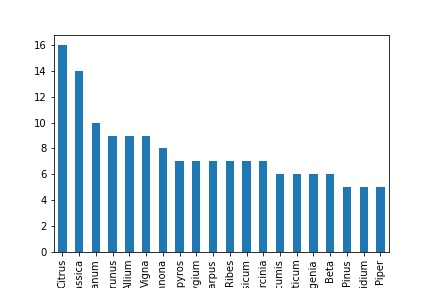

Distribution of crops by genus

#### Family

Figure 2 shows the distribution of crops by family.We can see the top 20 family categories in the scraped data below. Fabaceae is the top category, which contains several important agricultural products such as beans, pea, soybean, and peanuts. Poaceae is the second-largest and comprises the majority of cereal crops.

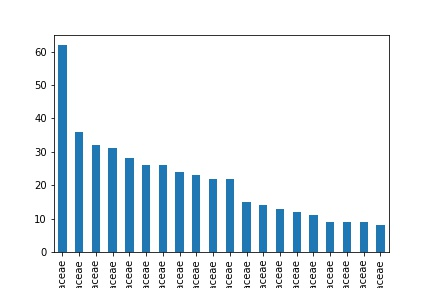

Distribution of crops by family

#### Order

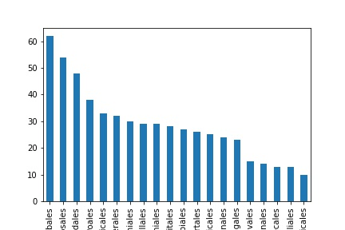

Distribution of crops by order

#### Pollination analysis

The pie chart (Figure 4) shows the distribution of crops by the number of pollination methods. We can see that while most crops have only one type of pollination, several crops have 2 types of pollination methods.

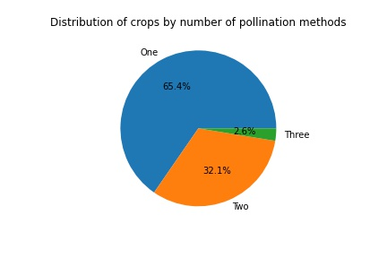

Pollination analysis

#### Climate and weather

We find that the majority of crops where climate data is available grow in only one type of climate (107 out of 156). This makes sense because crop species are highly dependent on the weather patterns of their area of origin.

#### Crop categories

Figure 5 shows the distribution of crops by number of categories under which they can be classified. Almost all crops belong to multiple categories, and most crops belong to 3 or 4 categories. This might be related to the fact that world crop databases would tend to index crops which have multiple uses, are very widespread, and are of great importance to the general population.

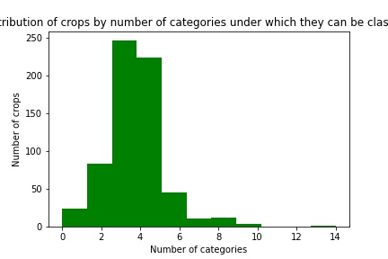

Crops by number of categories

#### Analysis of names

On average, the English language contains the most variants of names for crops (3.15), compared to Dutch (1.51), Spanish (1.51), French (1.52), and German (1.99)

Figure 6 shows the distribution of crops by number of English names. Most crops have between 1 to 5 names.

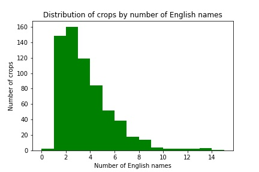

Distribution of crops by number of English names

#### Annual, biennial, or perennial

Of all the crops with cropping pattern data (90 crops), we find that 71 belong to only one category and 19 crops to two categories. Most of the crops have only type of cropping pattern reported. This makes sense because an annual or biennial crop cannot be perennial as well.